# DATA SCIENCE LATAM

UN ESPACIO PARA NUNCA PARAR DE APRENDER!!

Francisco Zambrano Cruz. Abril 2020.

[figure not shown]

# PROBABILIDAD Y DISTRIBUCIONES

Los conceptos de aleatoriedad y probabilidad son fundamentales para las estadísticas. La distribución es vital para comprender los métodos estadísticos. En esta sección, describimos las ideas básicas de probabilidad y las funciones que R tiene para muestreo aleatorio y manejo de distribuciones teóricas.

En este documentos vermos los siguientes temas:

- Muestreo aleatorio.
- Cálculos de probabilidad y combinatoria.
- Las distribuciones en R:
- Densidad o probabilidad puntual.
- Probabilidad acumulada, función de distribución
- Cuantiles
- Números pseudo-aleatorios

## Muestreo aleatorio

Si tu desea elegir cinco números al azar del conjunto 1:40, entonces puedes escribir:

```r
sample(1:40,5)
```

1. 32

2. 30

3. 7

4. 33

5. 5

El primer **argumento (x)** es un vector de valores a muestrear y el segundo (tamaño) es el tamaño de la muestra. En realidad, **sample(40,5)** sería suficiente ya que un solo número se interpreta para representar la longitud de una secuencia de enteros.

El comportamiento predeterminado de la muestra es el **muestreo sin reemplazo**. Es decir, las muestras no contendrán el mismo número dos veces, y obviamente, el tamaño no puede ser mayor que la longitud del vector a muestrear.

Si desea muestrear con reemplazo, debe agregar el argumento **repalce = TRUE**.

```r
sample(c("H","T"), 10, replace=T)
```

1. 'T'

2. 'T'

3. 'T'

4. 'H'

5. 'H'

6. 'H'

7. 'H'

8. 'H'

9. 'H'

10. 'H'

Puede simular datos con probabilidades no iguales para el resultados (digamos, un 90% de posibilidades de éxito) al usar el argumento prob:

```r
sample(c("succ", "fail"), 10, replace=T, prob=c(0.9, 0.1))
```

1. 'fail'

2. 'succ'

3. 'succ'

4. 'succ'

5. 'succ'

6. 'succ'

7. 'succ'

8. 'succ'

9. 'succ'

10. 'succ'

## Cálculos de probabilidad y combinatoria.

Volvamos al caso del muestreo sin reemplazo, específicamente sample(1:40, 5). La probabilidad de obtener un número dado como el primero de la muestra debe ser 1/40, el siguiente 1/39, y así sucesivamente. La probabilidad de una muestra dada debe ser 1 / (40 × 39 × 38 × 37 × 36). En R, use la función prod, que calcula el producto de un vector de números:

```r
1/prod(40:36)
```

1.26644863486969e-08

Si este fuera un juego tipo **Lotto**, entonces estarías interesado en la probabilidad de adivinar un conjunto dado de cinco números correctamente. Por lo tanto, también debe incluir los casos que dan los mismos números en un orden diferente. Ya que la probabilidad de cada uno de estos casos va para ser el mismo, todo lo que tenemos que hacer es calcular cuántos casos hay y multiplicar por esos. Hay cinco posibilidades para el primer número, y para cada uno de estos hay cuatro posibilidades para el segundo, y así adelante; es decir, el número es **5 × 4 × 3 × 2 × 1**.

Este número también se escribe como **5! (5 factorial)**. Entonces la probabilidad de un "cupón ganador de Lotto" sería:

```r
prod(5:1)/prod(40:36)
```

1.51973836184363e-06

Hay otra forma de llegar al mismo resultado. Todos los conjuntos de cinco números deben tener el misma probabilidad. Entonces, todo lo que tenemos que hacer es calcular la cantidad de formas elegir 5 números de 40.

[figure not shown]

```r
1/choose(40,5)
```

1.51973836184363e-06

## Las distribuciones en R

Las distribuciones estándar que aparecen en relación con la construcción de modelos y las pruebas estadísticas se han incorporado a R, y por lo tanto puede completamente reemplazar las tablas estadísticas tradicionales. Aquí solo miramos la distribución normal y la distribución binomial, pero siguen otras distribuciones exactamente el mismo patrón.

Se pueden calcular cuatro elementos fundamentales para una distribución estadística:

• Densidad o probabilidad puntual.

• Probabilidad acumulada, función de distribución

• Cuantiles

• Números pseudo-aleatorios

Para todas las distribuciones implementadas en R, hay una función para cada una de las cuatro elementos enumerados anteriormente. Por ejemplo, para la distribución normal, estos son llamado **dnorm, pnorm, qnorm y rnorm (densidad, probabilidad, cuantil, y aleatorio, respectivamente).**

## Densidades

La densidad para una distribución continua es una medida de la probabilidad relativa de "obtener un valor cercano a x". La probabilidad de obtener un valor en un intervalo particular es el área debajo de la parte correspondiente de la curva.

Para distribuciones discretas, el término "densidad" se usa para la probabilidad puntual, la probabilidad de obtener exactamente el valor x. Técnicamente, esto es correcto: es una densidad con respecto a la medida de conteo.

- Grafica de densidad de una distribucion normal:

[figure not shown]

Si desea dibujar la curva de campana de la distribución normal, entonces se puede hacer así:

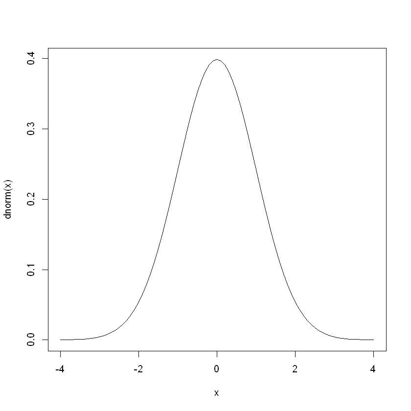

```r
x <- seq(-4,4,0.1)
plot(x,dnorm(x),type="l")
```

El uso de **type = "l"** (letra L miniscula) como argumento para trazar hace que la función dibuje líneas entre los puntos en lugar de trazar los puntos en sí.

Otra alternativa para dibujar la curva:

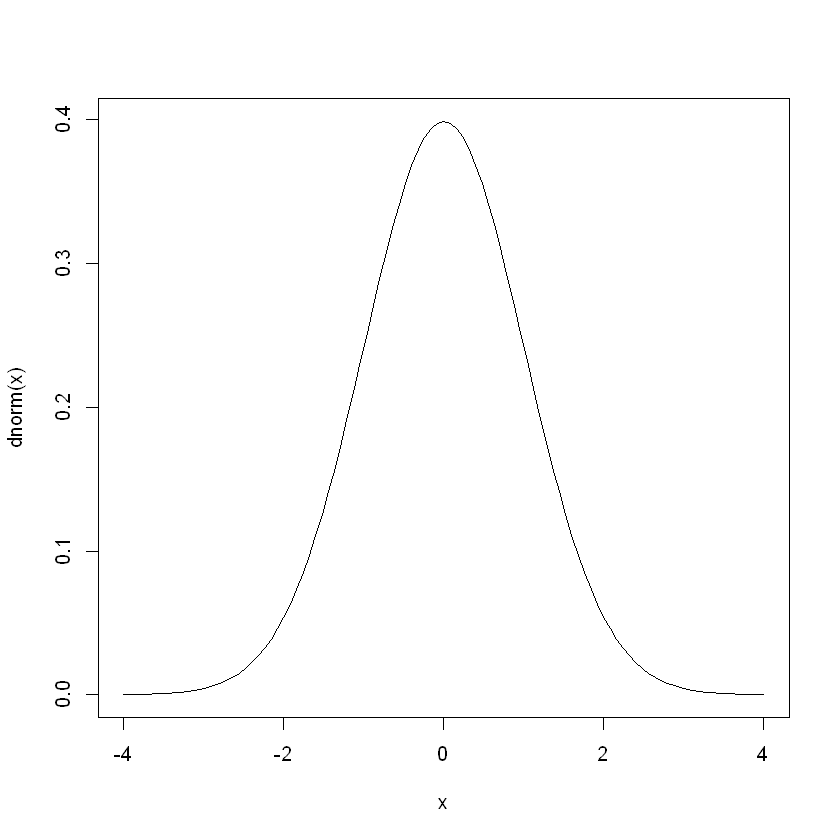

```r
curve(dnorm(x), from=-4, to=4)
```

Para **distribuciones discretas**, donde las variables solo pueden tomar valores distintos, aquí para la distribución binomial con n = 50 y p = 0.33:

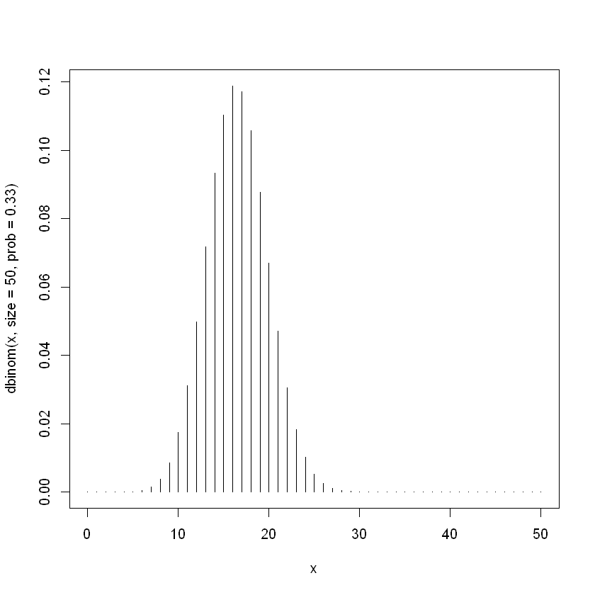

```r
x <- 0:50
plot(x,dbinom(x,size=50,prob=.33),type="h")
```

Tenga en cuenta que esta vez hay tres argumentos para la **"función d"**.

Además de x, debe especificar el número de intentos n y la probabilidad parámetro p.

En realidad, **dnorm** también toma más de un argumento, la media y la desviación estándar. Pero tienen valores predeterminados de 0 y 1, respectivamente, ya que la mayoría de las veces es la distribución normal estándar que se solicita.

La forma 0:50 es una versión corta de seq (0,50,1):números enteros de 0 a 50.

El type = "h" (como en el histograma) que causa las lineas dibujadas.

## Funciones de distribución acumulativa.

Digamos que se sabe que algunos bioquímicos, la medida en individuos sanos está bien descrita por una distribución normal con una media de 132 y una desviación estándar de 13. Entonces, si un paciente tiene un valor de 160:

```r
1-pnorm(160,mean=132,sd=13)
```

0.0156261194284694

El 1.5% de la población general que tiene mayor a ese valor.

La función pnorm devuelve la probabilidad de obtener un valor menor que su primer argumento en una distribución normal con la media dada y Desviación Estándar.

## Cuantiles

La función cuantil es la inversa de la función de distribución acumulativa. El **p-cuantil** es el valor con la propiedad de que hay probabilidad p de obtener un valor menor o igual a él. La mediana es, por definición, el 50% cuantil. Las tablas de distribuciones estadísticas casi siempre se dan en términos de cuantiles.

Si tenemos **n** observaciones **distribuidas normalmente con media μ y desviación estándar SIGMA**, entonces se sabe que el **xPromedio** es normalmente distribuido alrededor de **μ** con desviación estándar **sigma/raiz(n)**. Un 95% de confianza de intervalo para μ se puede obtener como:

[figure not shown]

donde N 0.025 es el cuantil del 2.5% en la distribución normal.

Si sigma = 12 y n = 5 y xpromedio = 83, entonces podemos calcular el intervalo para **μ**.

("sem" = standard error of the mean)

```r
xbar <- 83
sigma <- 12
n <- 5
sem <- sigma/sqrt(n)
sem
```

5.3665631459995

```r
xbar + sem * qnorm(0.025)
```

72.481729513081

```r
xbar + sem * qnorm(0.975)
```

93.518270486919

y así encontramos un intervalo de confianza del 95% para μ que va de 72.48 a 93.52. (Observe que esto se basa en la suposición de que se conoce sigma).

Como se sabe que la distribución normal es simétrica, de modo que N0.025 = −N0.975

Otra aplicación de cuantiles está relacionada con los gráficos Q – Q. que puede usarse para evaluar si un conjunto de datos puede se puede suponer razonablemente que proviene de una distribución dada.

## Números Aleatorios

Es posible es generar secuencias de números "pseudoaleatorios", que a efectos prácticos se comportan como si fueron hechos al azar. En estadística, se utilizan para crear datos simulados. establece para estudiar la precisión de aproximaciones matemáticas y el efecto de los supuestos violados. El uso de las funciones que generan números aleatorios es sencillo. El primer argumento especifica el número de números aleatorios para calcular, y los argumentos posteriores son similares a los de las otras funciones relacionadas con las mismas distribuciones. Por ejemplo:

```r
rnorm(10)
```

1. -0.656087678518268

2. -1.03149478825373

3. -2.36537088121216

4. 0.745266610608206

5. -0.615133534635297

6. -0.355023940799504

7. 0.774039805555171

8. 1.5261665007352

9. -0.23035210811869

10. -1.12550787670028

```r
rnorm(10)
```

1. 1.53681260063142

2. -1.14255461497053

3. -0.102475573199999

4. -1.23323905641489

5. -0.504674291757518

6. -0.822567296182553

7. -1.15522480357108

8. 0.564521232170046

9. 1.17606776823341

10. -0.0437057172472498

```r
rnorm(10,mean=7,sd=5)
```

1. 12.3977754694931

2. 9.42694332005014

3. 7.67575969159048

4. 5.34149869321998

5. 6.57033579199148

6. 14.8310049527195

7. 12.0846752043394

8. -2.03737885248534

9. 7.35380566855599

10. 5.43650267883264

```r
rbinom(10,size=20,prob=.5)
```

1. 6

2. 10

3. 11

4. 10

5. 9

6. 9

7. 12

8. 7

9. 10

10. 13

Fuente: Introductory Statistics with R, Second Edition. Springer